# MD05

2023-10-12

```r
library(tidyverse)
twitch_data <- read_csv("https://raw.githubusercontent.com/vaiseys/dav-course/main/Data/twitchdata-update.csv")
library(janitor)
twitch_data <- clean_names(twitch_data)

colnames(twitch_data)
```

```
##  [1] "channel"             "watch_time_minutes"  "stream_time_minutes"
##  [4] "peak_viewers"        "average_viewers"     "followers"
##  [7] "followers_gained"    "views_gained"        "partnered"
## [10] "mature"              "language"
```

## Question1

```r
library(dplyr)

random_streamers <- twitch_data %>% sample_n(5)
random_streamers %>%
select(channel,average_viewers,followers)
```

```
## # A tibble: 5 × 3
##   channel                   average_viewers followers
##   <chr>                               <dbl>     <dbl>
## 1 Xari                                 4841    269447
## 2 AnthonyZ                             1216    199617
## 3 과로사1 (aram4519)                   1592    301329
## 4 Call of Duty (callofduty)           19897    968465
## 5 XEWER                                1660    455056
```

```r
random_streamers
```

```
## # A tibble: 5 × 11
##   channel    watch_time_minutes stream_time_minutes peak_viewers average_viewers
##   <chr>                   <dbl>               <dbl>        <dbl>           <dbl>
## 1 Xari                361741665               80535        28830            4841
## 2 AnthonyZ            154524165              117735         7416            1216
## 3 과로사1 (…          136944300               81570        14167            1592
## 4 Call of D…          130938960                3645       170131           19897
## 5 XEWER               315398565              189315        17100            1660
## # ℹ 6 more variables: followers <dbl>, followers_gained <dbl>,
## #   views_gained <dbl>, partnered <lgl>, mature <lgl>, language <chr>
```

```r
library(dplyr)

twitch_data %>%
  select(average_viewers, followers) %>%
  summary()
```

```
##  average_viewers    followers
##  Min.   :   235   Min.   :   3660
##  1st Qu.:  1458   1st Qu.: 170546
##  Median :  2425   Median : 318063
##  Mean   :  4781   Mean   : 570054
##  3rd Qu.:  4786   3rd Qu.: 624332
##  Max.   :147643   Max.   :8938903
```

The average viewers among all streamers is 4781, and the average followers is 570054. There is a significant difference between median and mean, which could mean that some streamers have exceptionally high numbers in average viewers and the followers.

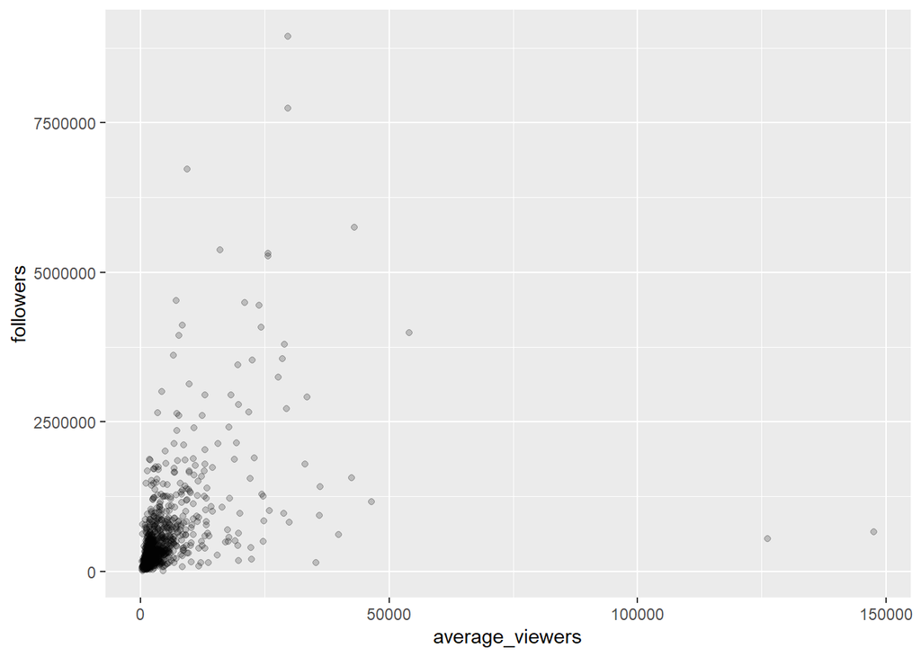

```r
library(ggplot2)
ggplot(data = twitch_data,
       mapping = aes(x = average_viewers, y = followers))+
  geom_point(alpha = 0.2)
```

Most of the data cluttered together under 25000 average viewers and under 2500000 followers, but still some streamers have significant high values.

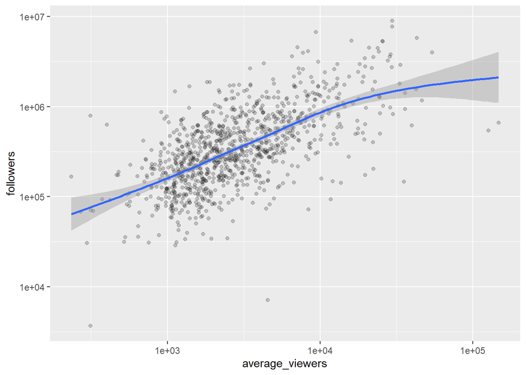

```r
ggplot(data = twitch_data, mapping = aes(x = average_viewers, y = followers)) +
  geom_point(alpha = 0.2) +
  geom_smooth()+
  scale_x_log10()+
  scale_y_log10()
```

```r
twitch_data <- twitch_data %>%
  mutate(log_viewers = log10(average_viewers),
         log_followers = log10(followers))
```

## Question2

Using `lm()` fit a model where you predict the logarithm of average viewers (`log_viewers`) using the logarithm of followes (`log_followers`). Save the results to an object called `fit1`.

```r
fit1 <- lm(log_viewers ~ log_followers, data = twitch_data)

broom::tidy(fit1)
```

```
## # A tibble: 2 × 5
##   term          estimate std.error statistic   p.value
##   <chr>            <dbl>     <dbl>     <dbl>     <dbl>
## 1 (Intercept)      0.198    0.125       1.58 1.15e-  1
## 2 log_followers    0.588    0.0226     26.0  1.69e-114
```

```r
library(broom)
tidy(fit1)
```

```
## # A tibble: 2 × 5
##   term          estimate std.error statistic   p.value
##   <chr>            <dbl>     <dbl>     <dbl>     <dbl>
## 1 (Intercept)      0.198    0.125       1.58 1.15e-  1
## 2 log_followers    0.588    0.0226     26.0  1.69e-114
```

It is weird that get_regression_table doesn’t work on my computer but broom::tidy() does work.

## Question3

```r
library(broom)

pred_data <- augment(fit1)

glimpse(pred_data)
```

```
## Rows: 1,000
## Columns: 8
## $ log_viewers   <dbl> 4.442731, 4.408410, 4.040444, 3.887280, 4.471321, 4.6275…
## $ log_followers <dbl> 6.511388, 6.725108, 6.247393, 6.596030, 6.951284, 6.1940…
## $ .fitted       <dbl> 4.029761, 4.155534, 3.874400, 4.079572, 4.288638, 3.8430…
## $ .resid        <dbl> 0.4129697, 0.2528757, 0.1660436, -0.1922928, 0.1826833, …
## $ .hat          <dbl> 0.006194481, 0.008694557, 0.003782169, 0.007126066, 0.01…
## $ .sigma        <dbl> 0.3085580, 0.3087321, 0.3087919, 0.3087764, 0.3087820, 0…
## $ .cooksd       <dbl> 0.0056128779, 0.0029688873, 0.0005513456, 0.0014026033, …
## $ .std.resid    <dbl> 1.3420109, 0.8227954, 0.5389316, -0.6251793, 0.5953620, …
```

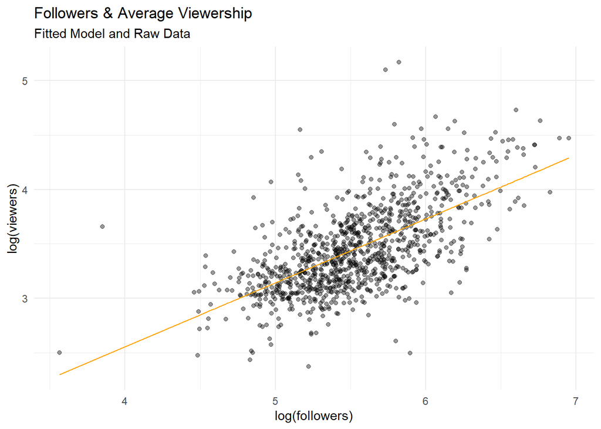

```r
pred_data %>%
  ggplot(aes(x = log_followers,
             y = log_viewers)) +
  geom_jitter(alpha = 0.4) +
  geom_line(aes(x = log_followers,
                y = .fitted),
            col = "orange") +
  theme_minimal() +
  labs(subtitle = "Fitted Model and Raw Data",
       title = "Followers & Average Viewership",
       x = "log(followers)",
       y = "log(viewers)")
```

The orange line captures a general trend and indicates a positive linear relationship between log-transformed followers and log-transformed viewers. The jitter points are from the raw data, indicates variability.

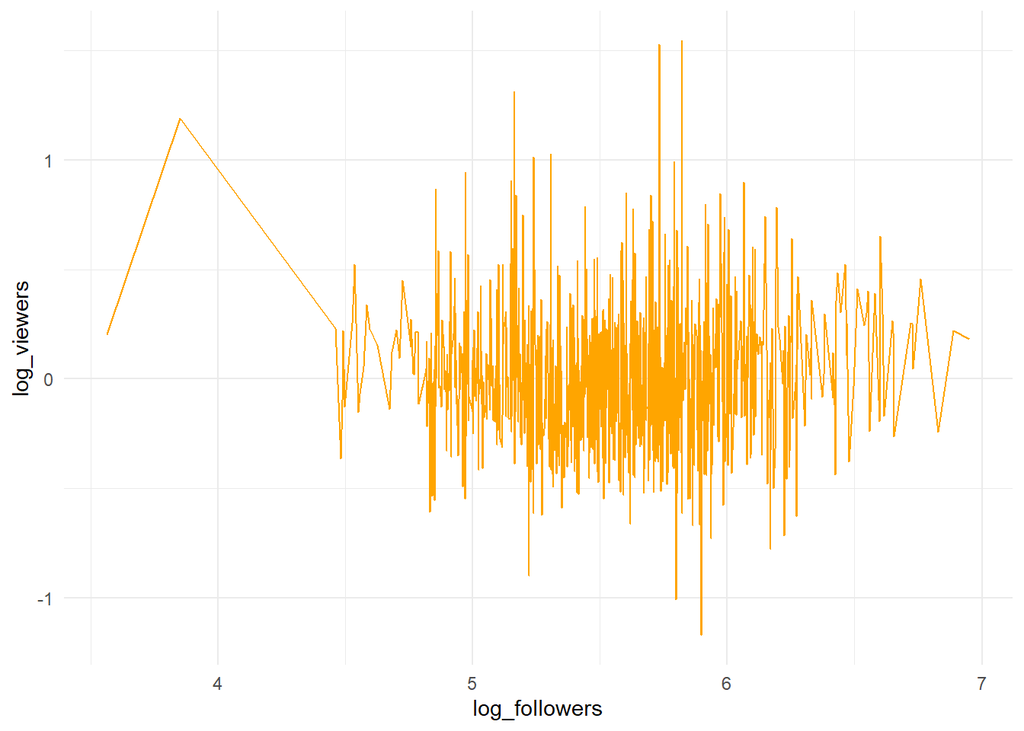

```r
pred_data %>%
  ggplot(aes(x = log_followers, y = log_viewers)) +
  geom_line(data = pred_data,
            mapping = aes(x = log_followers, y = .resid), col = "orange") +
  theme_minimal()
```

Residuals do happen often in a particular range in the x-axis (from 4.5 to 6.5). It means our model would systematically fail to predict part of our data.

## Question4

```r
head(twitch_data)
```

```
## # A tibble: 6 × 13
##   channel   watch_time_minutes stream_time_minutes peak_viewers average_viewers
##   <chr>                  <dbl>               <dbl>        <dbl>           <dbl>
## 1 xQcOW             6196161750              215250       222720           27716
## 2 summit1g          6091677300              211845       310998           25610
## 3 Gaules            5644590915              515280       387315           10976
## 4 ESL_CSGO          3970318140              517740       300575            7714
## 5 Tfue              3671000070              123660       285644           29602
## 6 Asmongold         3668799075               82260       263720           42414
## # ℹ 8 more variables: followers <dbl>, followers_gained <dbl>,
## #   views_gained <dbl>, partnered <lgl>, mature <lgl>, language <chr>,
## #   log_viewers <dbl>, log_followers <dbl>
```

```r
twitch_data %>%
  select(average_viewers, language) %>%
  summary()
```

```
##  average_viewers    language
##  Min.   :   235   Length:1000
##  1st Qu.:  1458   Class :character
##  Median :  2425   Mode  :character
##  Mean   :  4781
##  3rd Qu.:  4786
##  Max.   :147643
```

```r
table(twitch_data$language)
```

```
##
##     Arabic    Chinese      Czech    English    Finnish     French     German
##          5         30          6        485          1         66         49
##      Greek  Hungarian    Italian   Japanese     Korean      Other     Polish
##          1          2         17         10         77          1         12
## Portuguese    Russian     Slovak    Spanish    Swedish       Thai    Turkish
##         61         74          1         68          1         11         22
```

```
## No summary function supplied, defaulting to `mean_se()`
```

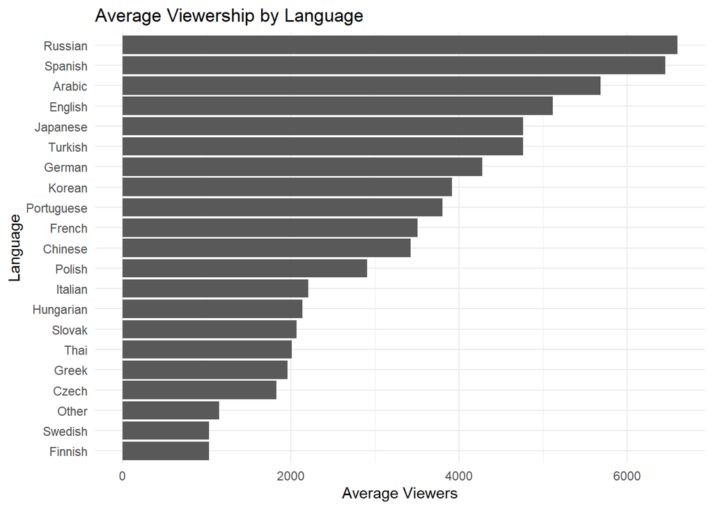

```r
ggplot(data = twitch_data,
         mapping = aes(x = reorder(language, average_viewers),
                       y = average_viewers)) +
  geom_bar(stat = "summary") +
  coord_flip()+
  theme_minimal() +
  labs(
    title = "Average Viewership by Language",
    x = "Language",
    y = "Average Viewers"
  )
```

Surprisingly English only ranked 4th among all the channels of all language. The language with most average viewers is Russian, followed by Spanish and Arabic.

## Question5

```r
twitch_data <- twitch_data %>%
  mutate(language = as.factor(language),
         language = relevel(language, ref = "English"))
```

```r
fit2 <- lm(average_viewers ~ language,
            data = twitch_data)

broom::tidy(fit2)
```

```
## # A tibble: 21 × 5
##    term              estimate std.error statistic  p.value
##    <chr>                <dbl>     <dbl>     <dbl>    <dbl>
##  1 (Intercept)          5113.      385.    13.3   3.47e-37
##  2 languageArabic        569.     3808.     0.150 8.81e- 1
##  3 languageChinese     -1688.     1594.    -1.06  2.90e- 1
##  4 languageCzech       -3285.     3480.    -0.944 3.45e- 1
##  5 languageFinnish     -4086.     8480.    -0.482 6.30e- 1
##  6 languageFrench      -1606.     1111.    -1.45  1.49e- 1
##  7 languageGerman       -835.     1270.    -0.657 5.11e- 1
##  8 languageGreek       -3152.     8480.    -0.372 7.10e- 1
##  9 languageHungarian   -2972.     6002.    -0.495 6.21e- 1
## 10 languageItalian     -2907.     2090.    -1.39  1.65e- 1
## # ℹ 11 more rows
```

## Question6

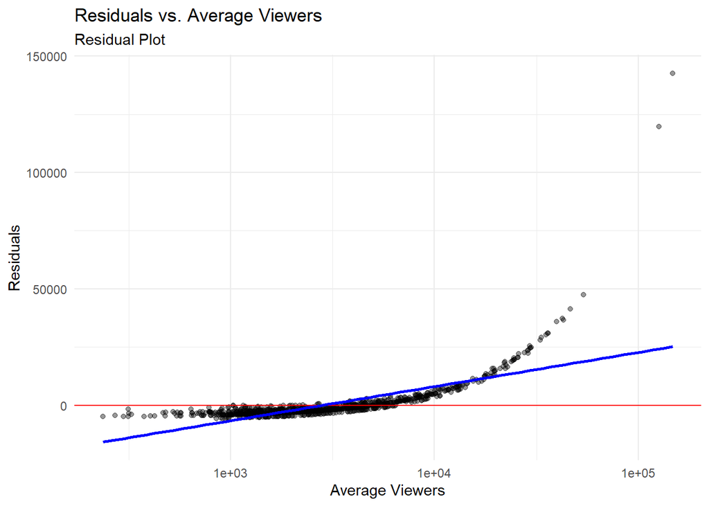

```r
pred_data <- augment(fit2)

residual_plot <- pred_data %>%
  ggplot(aes(x = average_viewers, y = .resid)) +
  geom_point(alpha = 0.4) +
  geom_hline(yintercept = 0, color = "red") +
  geom_smooth(method = "lm", se = FALSE, color = "blue") +
  scale_x_log10() +
  theme_minimal() +
  labs(subtitle = "Residual Plot", title = "Residuals vs. Average Viewers", x = "Average Viewers", y = "Residuals")

residual_plot
```

There are two points significantly deviated from the fitted regression line. Are they the missing points we should find?

[figure not shown]